# MA Group Assignment

Sriganesh Balamurugan – 11915001

Raghu Punnamraju – 11915010

Anmol More – 11915043

Ref : - https://www.r-bloggers.com/finding-optimal-number-of-clusters/

- https://www.datanovia.com/en/lessons/determining-the-optimal-number-of-clusters-3-must-know-methods/
- https://medium.com/codesmart/r-series-k-means-clustering-silhouette-794774b46586

## 1. Segment respondents based on the Partworth data (use any unsupervised learning technique).

```r
conjoint_data <- readxl::read_excel('Beer Partworth Data.xls', sheet = 'Conjoint Data', skip=13, n_max = 317)
```

```
## * Regular -> Regular...9
## * Regular -> Regular...15
```

```r
#skip the first column which contains respondent IDs, not required for clustering the data
conjoint_data <- conjoint_data[,-c(1)]
```

### First we apply various clustering algorithms to come up with best K.

In order to find best K, we looked at within cluster and between cluster Sum of square differences for k.

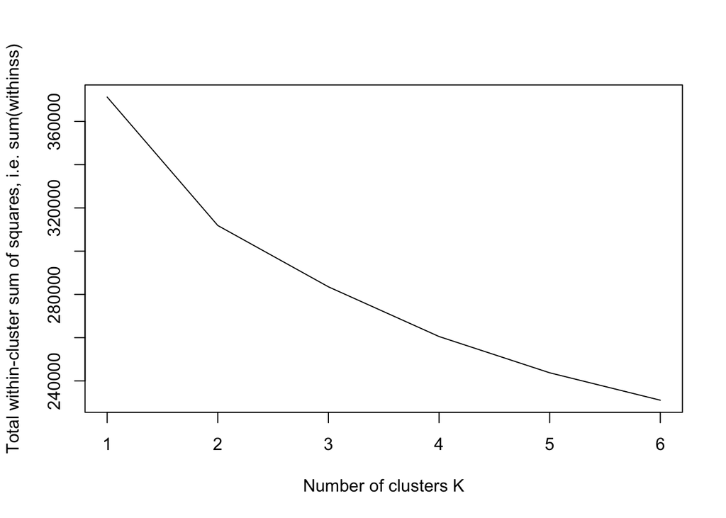

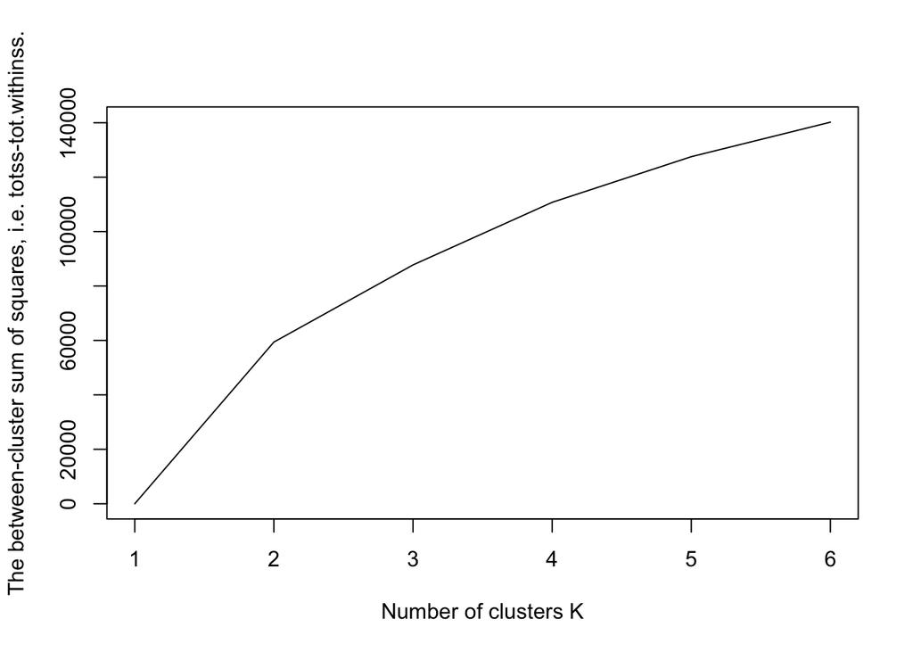

Looking at within cluster and between cluster differences, we can say that data can be divided in either 2 or 3 clusters.

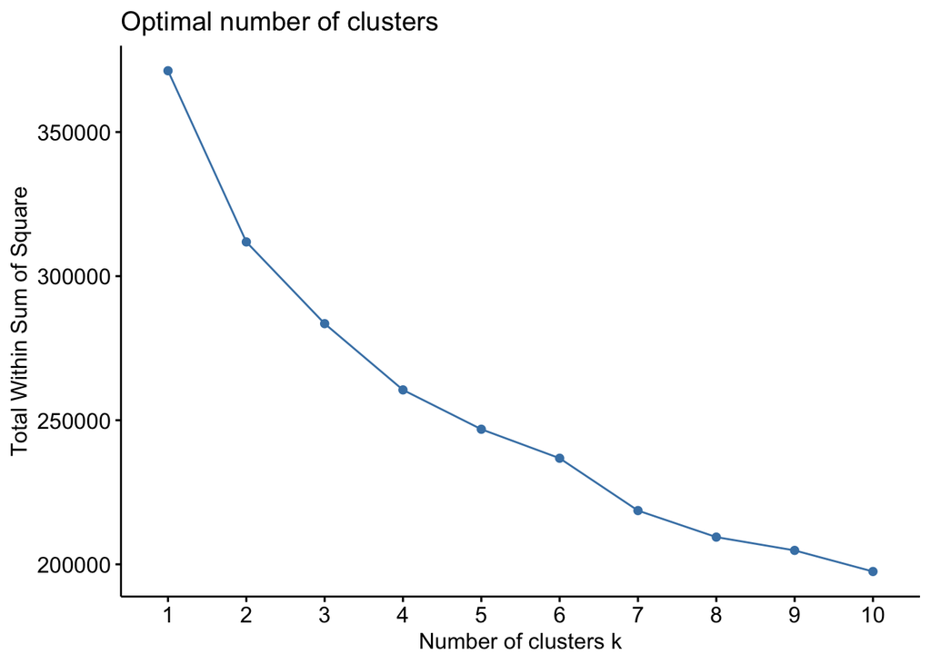

```r
# Elbow Method
fviz_nbclust(conjoint_data, kmeans, method = "wss")
```

```r
  labs(subtitle = "Elbow Method")
```

```
## $subtitle
## [1] "Elbow Method"
##
## attr(,"class")
## [1] "labels"
```

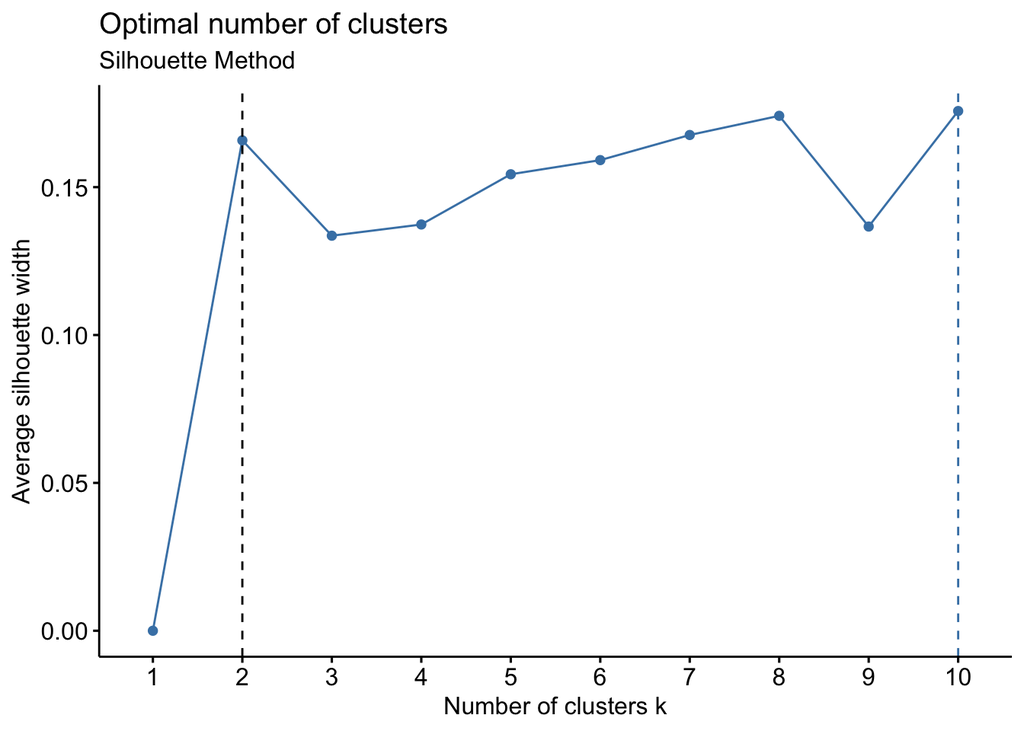

```r
# Silhouette Method
fviz_nbclust(conjoint_data, kmeans, method = "silhouette") +
  geom_vline(xintercept = 2, linetype = 2) +
  labs(subtitle = "Silhouette Method")
```

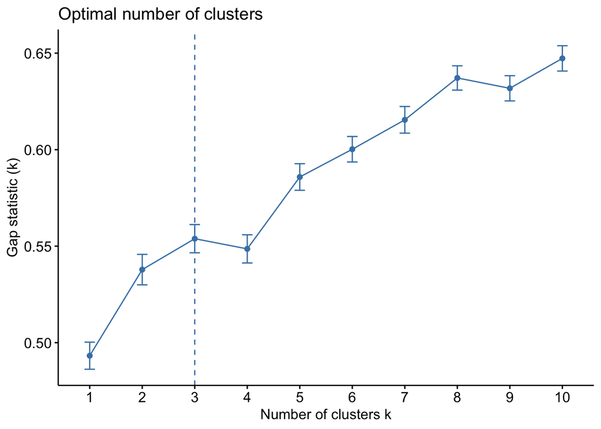

```r
# Gap statistic method doesn't gives a clear k
fviz_nbclust(conjoint_data, kmeans, method = "gap_stat")
```

```r
  labs(subtitle = "Gap Statistic Method")
```

```
## $subtitle
## [1] "Gap Statistic Method"
##
## attr(,"class")
## [1] "labels"
```

## 2. Use the Descriptors in the Demographic data sheet to perform classification (use any supervised learning technique) based on segments obtained in Step 1 and personify /describe each segment.

### Read demographics data and apply clusters obtained from conjoint data on Demographics data

```r
demographics_data <- readxl::read_excel('Beer Partworth Data.xls', sheet = 'Demographics', skip=3, n_max = 317)

#use two clusters
conjoint_data_cluster <- kmeans(conjoint_data, 2)$cluster
demographics_data$Cluster <- conjoint_data_cluster

#skip first column containing ID of respondents and clusters from conjoint data
data <- demographics_data[,-c(1)]
```

### Let’s plot various column to understand the distribution

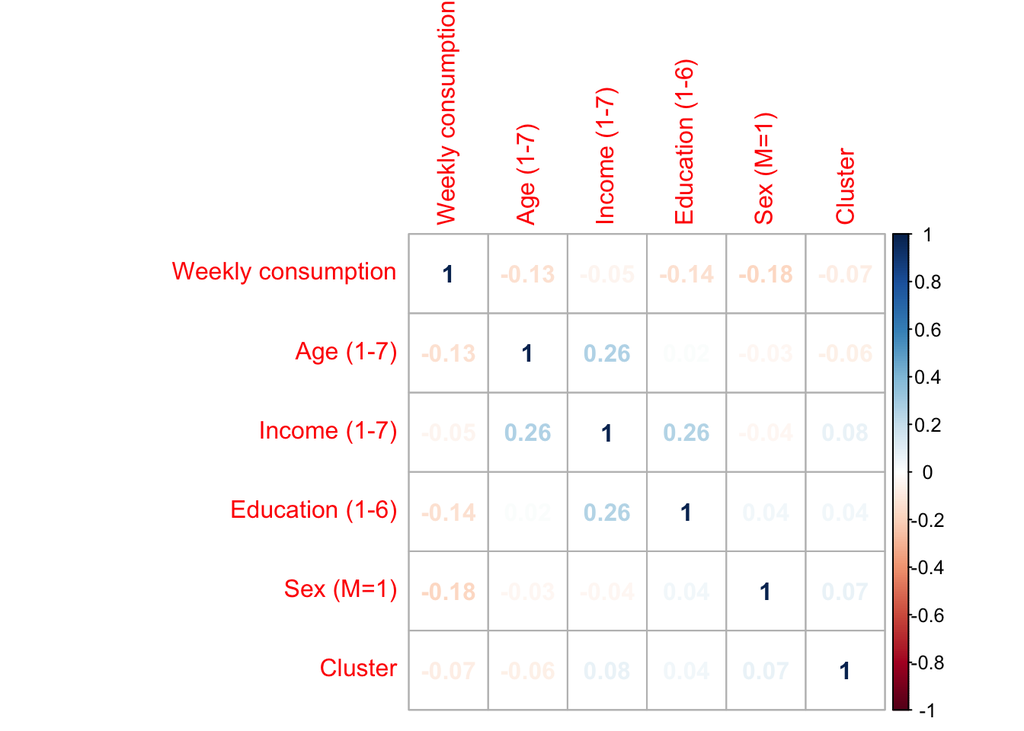

```r
#correlation plot surprisingly doesn't shows much correlation between Age, Income, Education or even with cluster (the target variable)
corrplot(cor(data), method = "number")
```

### we see from above correlation plot that, our clusters are not correlated to any variables, to some extent age, income and education are weakly correlated

Let us try to divide two set of people

```r
write.csv(data, file = "clustering data.csv", row.names=FALSE)
names(data) <- c('Weekly_Consumption', 'Age_Group', 'Income_Group', 'Education_Group',  'Sex', 'Cluster')
#data <- read.csv("clustering data.csv", colClasses=c('numeric', 'factor', 'factor', 'factor', 'factor', 'factor'))
```

Plot each variable against no. of clusters defined to identify reltionships

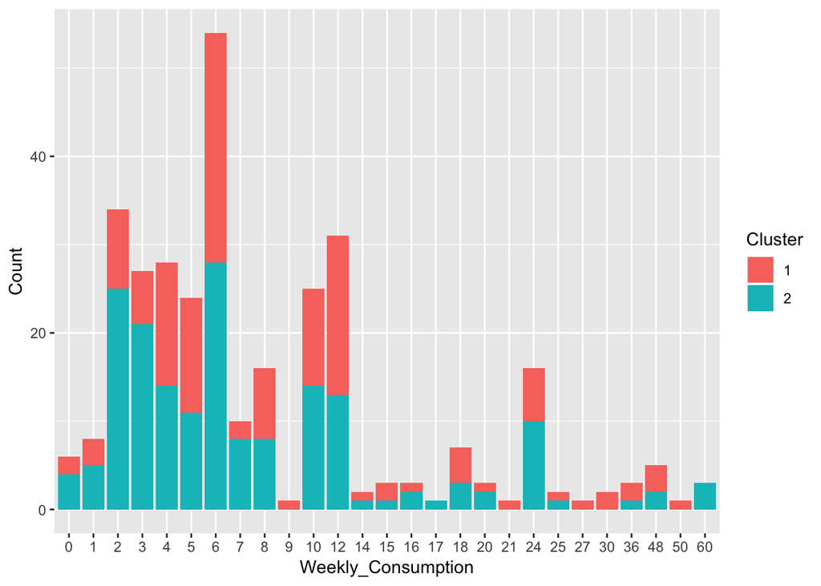

```r
pldata = data

#Weekly_Consumption vs Cluster
dat <- data.frame(table(pldata$Weekly_Consumption,pldata$Cluster))
names(dat) <- c("Weekly_Consumption","Cluster","Count")
ggplot(data=dat, aes(x=Weekly_Consumption, y=Count, fill=Cluster)) + geom_bar(stat="identity")
```

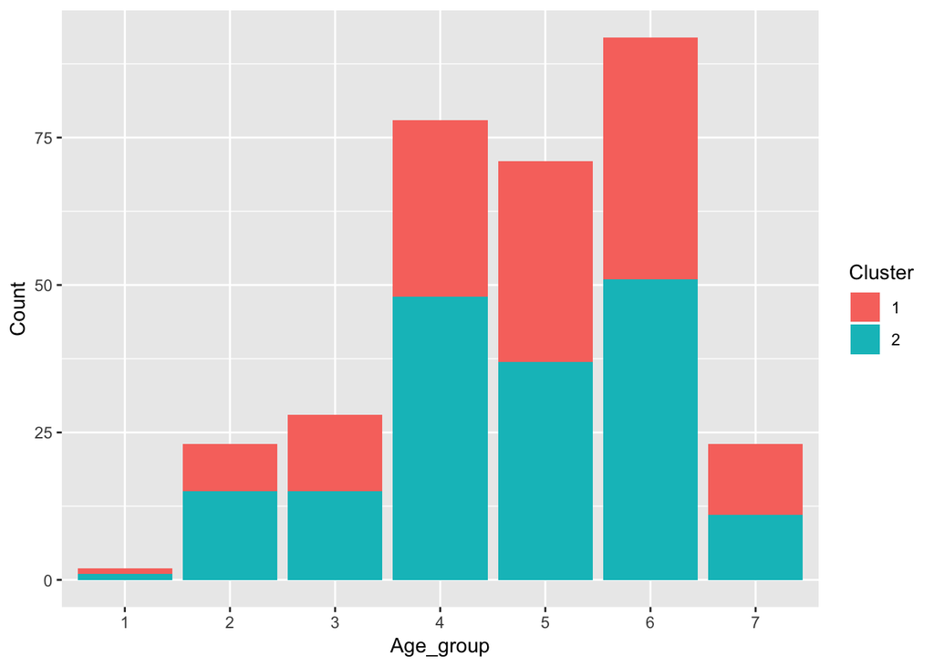

```r
#Age_group vs Cluster
dat <- data.frame(table(pldata$Age_Group,pldata$Cluster))
names(dat) <- c("Age_group","Cluster","Count")
ggplot(data=dat, aes(x=Age_group, y=Count, fill=Cluster)) + geom_bar(stat="identity")
```

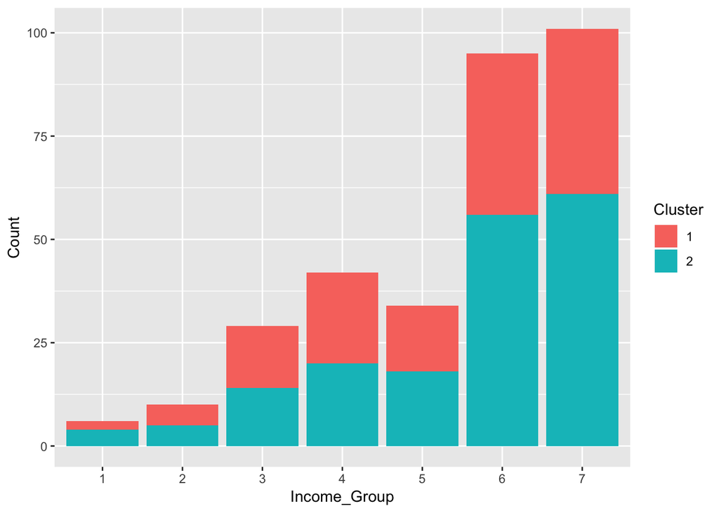

```r
#Income_Group vs Cluster
dat <- data.frame(table(pldata$Income_Group,pldata$Cluster))
names(dat) <- c("Income_Group","Cluster","Count")
ggplot(data=dat, aes(x=Income_Group, y=Count, fill=Cluster)) + geom_bar(stat="identity")
```

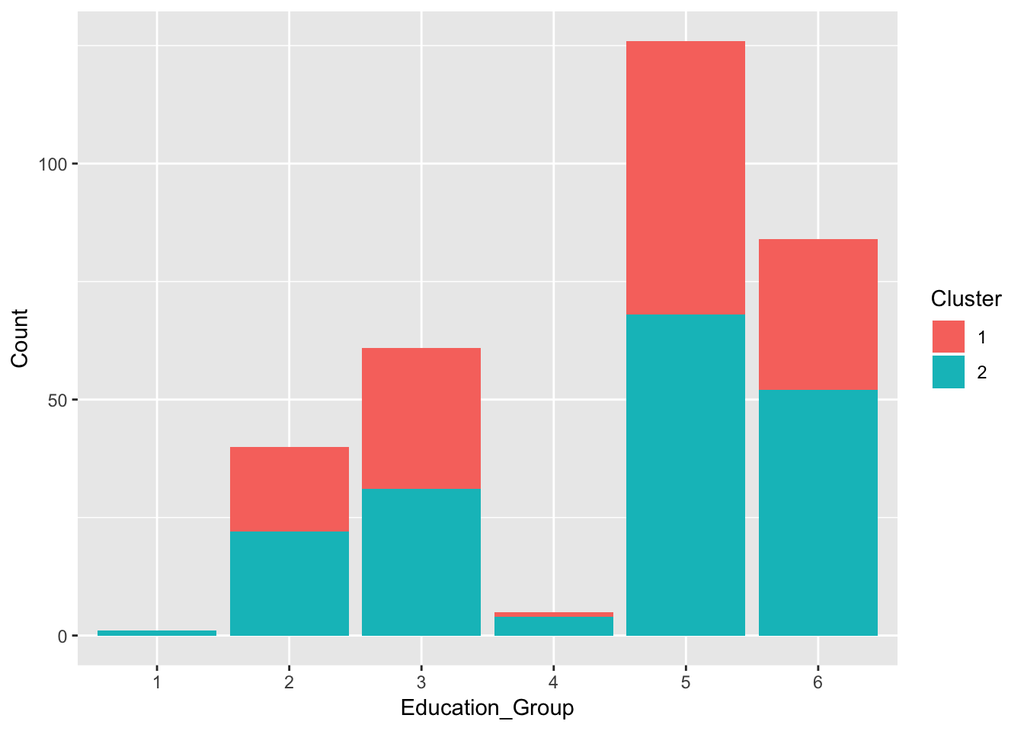

```r
#Education_Group vs Cluster
dat <- data.frame(table(pldata$Education_Group,pldata$Cluster))
names(dat) <- c("Education_Group","Cluster","Count")
ggplot(data=dat, aes(x=Education_Group, y=Count, fill=Cluster)) + geom_bar(stat="identity")
```

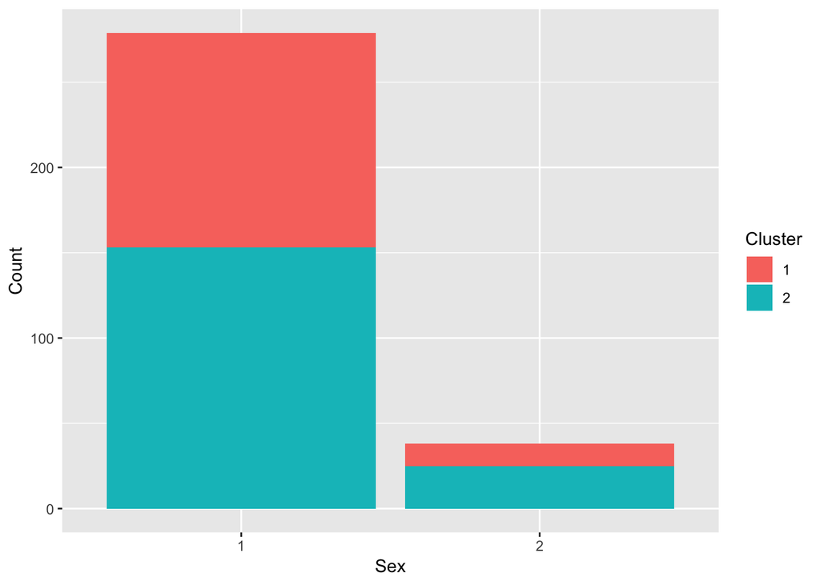

```r
#Sex vs Cluster
dat <- data.frame(table(pldata$Sex,pldata$Cluster))
names(dat) <- c("Sex","Cluster","Count")
ggplot(data=dat, aes(x=Sex, y=Count, fill=Cluster)) + geom_bar(stat="identity")
```

check summary of data to understand distribution of each of the variables

```r
describe(data)
```

```
## data
##
##  6  Variables      317  Observations
## ---------------------------------------------------------------------------
## Weekly_Consumption
##        n  missing distinct     Info     Mean      Gmd      .05      .10
##      317        0       27     0.99     9.42    8.941        2        2
##      .25      .50      .75      .90      .95
##        4        6       12       24       25
##
## lowest :  0  1  2  3  4, highest: 30 36 48 50 60
## ---------------------------------------------------------------------------
## Age_Group
##        n  missing distinct     Info     Mean      Gmd
##      317        0        7    0.948     4.77    1.523
##
## Value          1     2     3     4     5     6     7
## Frequency      2    23    28    78    71    92    23
## Proportion 0.006 0.073 0.088 0.246 0.224 0.290 0.073
## ---------------------------------------------------------------------------
## Income_Group
##        n  missing distinct     Info     Mean      Gmd
##      317        0        7    0.936    5.451    1.686
##
## Value          1     2     3     4     5     6     7
## Frequency      6    10    29    42    34    95   101
## Proportion 0.019 0.032 0.091 0.132 0.107 0.300 0.319
## ---------------------------------------------------------------------------
## Education_Group
##        n  missing distinct     Info     Mean      Gmd
##      317        0        6    0.909    4.473    1.509
##
## Value          1     2     3     4     5     6
## Frequency      1    40    61     5   126    84
## Proportion 0.003 0.126 0.192 0.016 0.397 0.265
## ---------------------------------------------------------------------------
## Sex
##        n  missing distinct     Info     Mean      Gmd
##      317        0        2    0.317     1.12   0.2117
##
## Value         1    2
## Frequency   279   38
## Proportion 0.88 0.12
## ---------------------------------------------------------------------------
## Cluster
##        n  missing distinct     Info     Mean      Gmd
##      317        0        2    0.739    1.562    0.494
##
## Value          1     2
## Frequency    139   178
## Proportion 0.438 0.562
## ---------------------------------------------------------------------------
```

### Run random forest

supervised learning technique to classify data

```r
data <- read.csv("clustering data.csv", colClasses=c('numeric', 'factor', 'factor', 'factor', 'factor', 'factor'))
names(data) <- c('Weekly_Consumption', 'Age_Group', 'Income_Group', 'Education_Group',  'Sex', 'Cluster')
random_forest_tree = randomForest(Cluster~., data = data)
summary(random_forest_tree)
```

```
##                 Length Class  Mode
## call               3   -none- call
## type               1   -none- character
## predicted        317   factor numeric
## err.rate        1500   -none- numeric
## confusion          6   -none- numeric
## votes            634   matrix numeric
## oob.times        317   -none- numeric
## classes            2   -none- character
## importance         5   -none- numeric
## importanceSD       0   -none- NULL
## localImportance    0   -none- NULL
## proximity          0   -none- NULL
## ntree              1   -none- numeric
## mtry               1   -none- numeric
## forest            14   -none- list
## y                317   factor numeric
## test               0   -none- NULL
## inbag              0   -none- NULL
## terms              3   terms  call
```

### Run gradient boosted trees

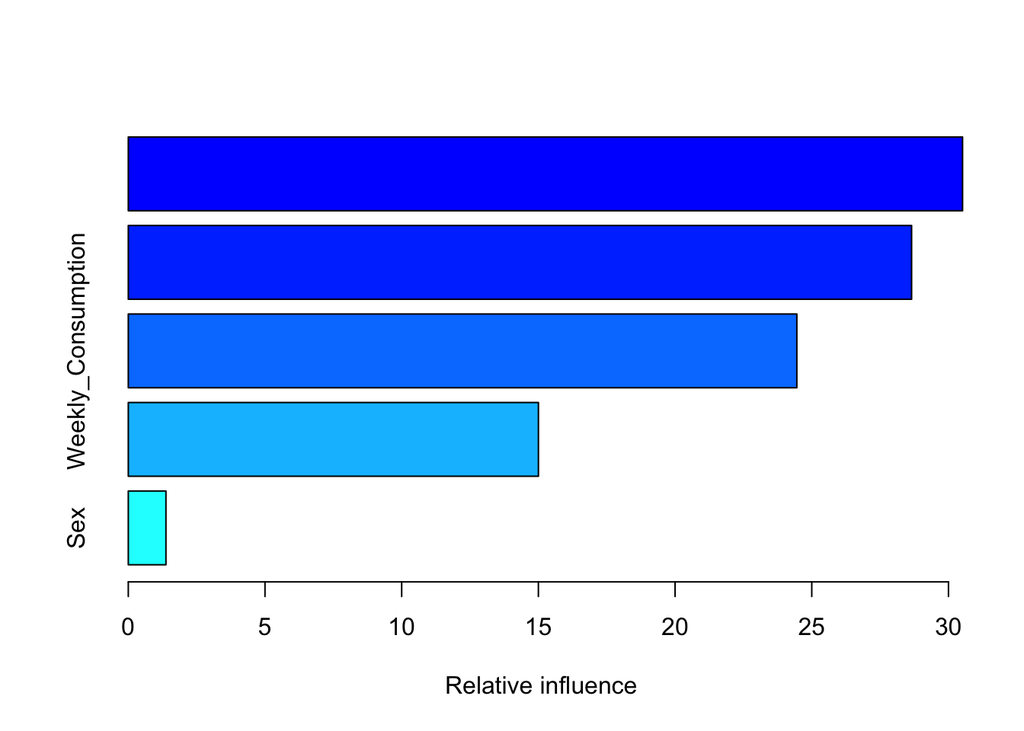

|  | var | rel.inf |
| --- | --- | --- |
| Income_Group | Income_Group | 30.515456 |
| Age_Group | Age_Group | 28.651370 |
| Weekly_Consumption | Weekly_Consumption | 24.454245 |
| Education_Group | Education_Group | 15.001676 |
| Sex | Sex | 1.377253 |

```r
library(gbm)
gradient_boosted_tree = gbm(Cluster~., data = data, distribution = "gaussian")
summary(gradient_boosted_tree)
```

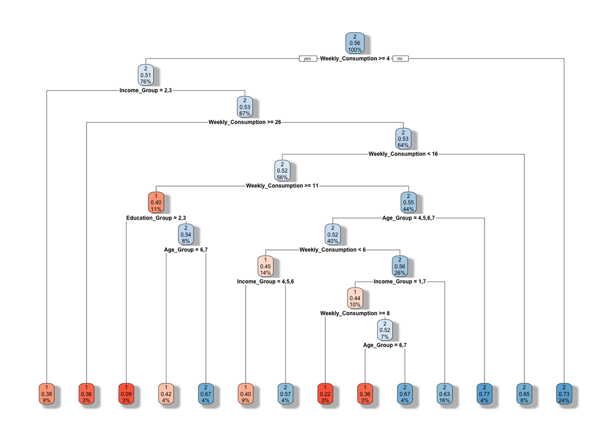

```r
# Create a decision tree model
tree <- rpart(Cluster~., data = data)
# Visualize the decision tree with rpart.plot
rpart.plot(tree, box.palette="RdBu", shadow.col="gray")
```

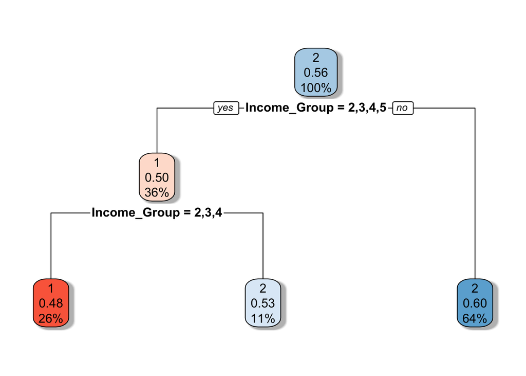

```r
# Create a decision tree to differentiate between different income groups
tree <- rpart(Cluster~Income_Group, data = data)
rpart.plot(tree, box.palette="RdBu", shadow.col="gray")
```

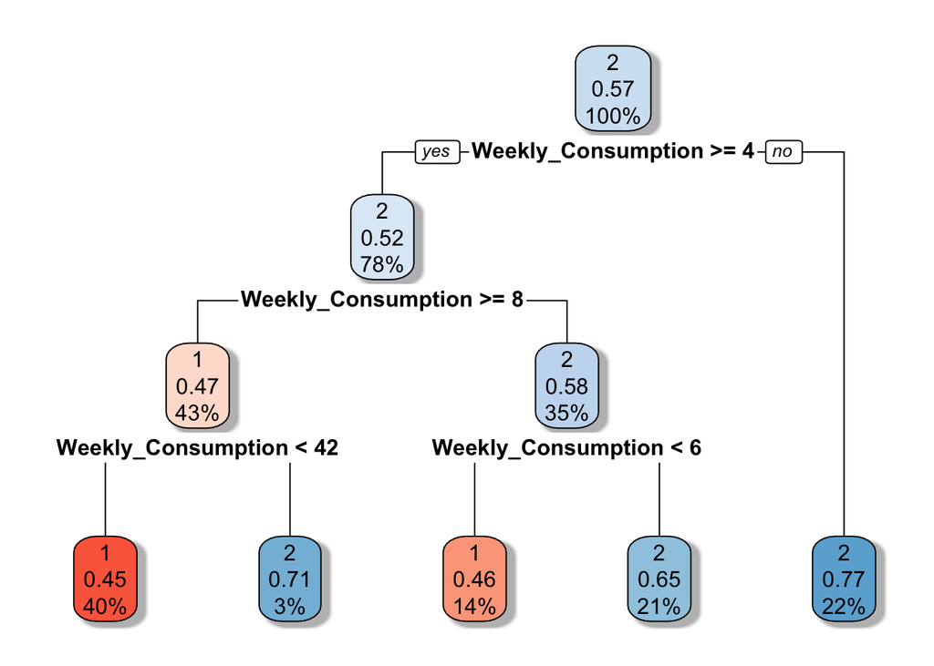

```r
subset_data <- data[data$Age_Group == "1" | data$Age_Group == "2" | data$Age_Group == "3" | data$Age_Group == "4"| data$Age_Group == "5", ]
tree <- rpart(Cluster~Weekly_Consumption, data = subset_data)

# Visualize the tree in younger age group
rpart.plot(tree, box.palette="RdBu", shadow.col="gray")
```

Some further analysis on higher age group 40+ age, shows 50%+ fall in cluster 2

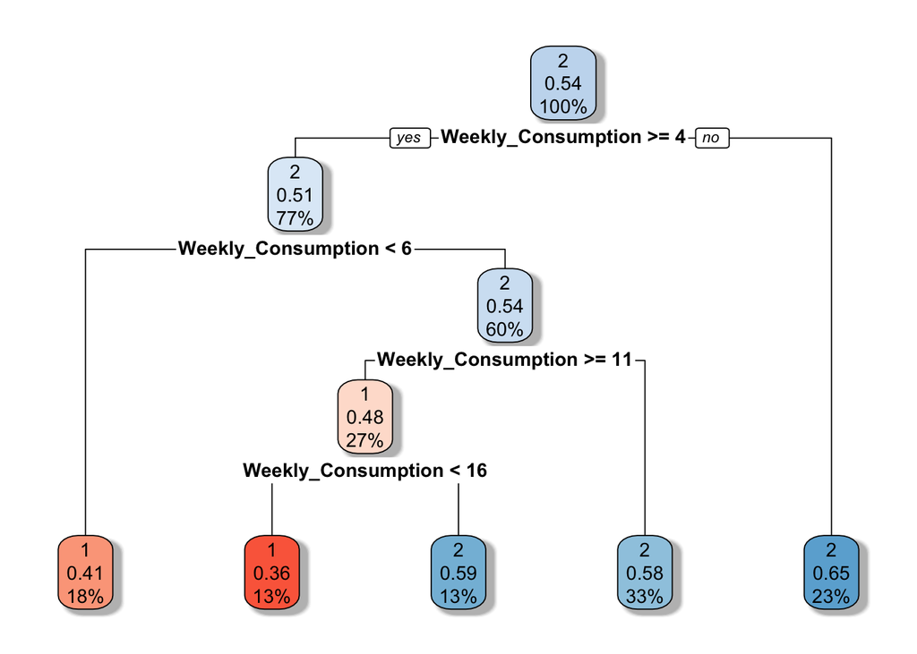

```r
subset_data <- data[data$Age_Group == "5" | data$Age_Group == "6", ]
tree <- rpart(Cluster~Weekly_Consumption, data = subset_data)

# Visualize tree for weekly consumption in older age group
rpart.plot(tree, box.palette="RdBu", shadow.col="gray")
```

plot pyramid graph to see what are most important attributes for customers in each cluster.

Important observations -

People in cluster 1 prefer - Brown painted, Cannadian beers

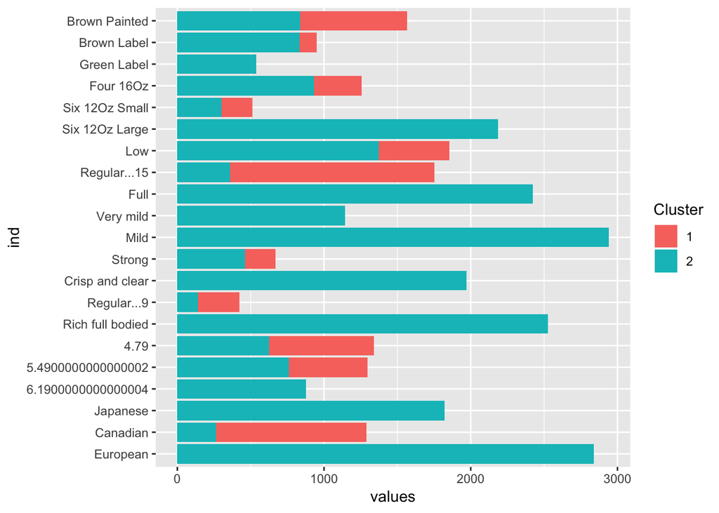

```r
#copy conjoint data to new dataframe
cd = conjoint_data

#assign clusters calculated
cd$Cluster = conjoint_data_cluster

dd = cbind(cd[22], stack(cd[-22]))
dd$Cluster = as.factor(dd$Cluster)

pyramidGH <- ggplot(dd, aes(x = ind, y = values, fill = Cluster)) +
  geom_bar(data = subset(dd, Cluster == 1), stat = "identity") +
  geom_bar(data = subset(dd, Cluster == 2), stat = "identity") +
  coord_flip()
pyramidGH
```

Finally we can divide the whole data in two groups -